# Data analysis of influences on health and economy by severe weather events

## Synopsis

The goal of this analysis is to find the severe weather events which have the most damaging influence on public health and economy through the data from 1950~2011. For public health, the total injuries and fatalities were calculated for each severe weather event. And for economy, the crop damage and property damage were calculated for for each severe weather event. Figures were generated to illustrate the damaging effect for top 30 severe weather event. From the figures, we can conclude that tornados are the biggest cause for both fatalities and injuries. Flooding causes most property damage and overall economic damage, whereas drought causes most crop damage.

## Introduction

Storms and other severe weather events can cause both public health and economic problems for communities and municipalities. Many severe events can result in fatalities, injuries, and property damage, and preventing such outcomes to the extent possible is a key concern.

This project involves exploring the U.S. National Oceanic and Atmospheric Administration’s (NOAA) storm database. This database tracks characteristics of major storms and weather events in the United States, including when and where they occur, as well as estimates of any fatalities, injuries, and property damage. The data can be download through link [Storm Data [47Mb]](https://d396qusza40orc.cloudfront.net/repdata%2Fdata%2FStormData.csv.bz2)

## Process data

### Load data to R

1.Load packages for data analysis 2.Download unzip and read the file through data.table

```r
library(data.table)
library(R.utils)
library(dplyr)
```

```r
library(ggplot2)
urlfile<-"https://d396qusza40orc.cloudfront.net/repdata%2Fdata%2FStormData.csv.bz2"
download.file(urlfile,"StormData.csv.bz2")
bunzip2("StormData.csv.bz2")
datatb<-fread("StormData.csv")
```

```
##
Read 27.9% of 967216 rows
Read 53.8% of 967216 rows
Read 73.4% of 967216 rows
Read 83.7% of 967216 rows
Read 902297 rows and 37 (of 37) columns from 0.523 GB file in 00:00:06
```

```r
unlink("StormData.csv")
datatb[1:10]
```

```
##     STATE__           BGN_DATE BGN_TIME TIME_ZONE COUNTY COUNTYNAME STATE
##  1:       1  4/18/1950 0:00:00     0130       CST     97     MOBILE    AL
##  2:       1  4/18/1950 0:00:00     0145       CST      3    BALDWIN    AL
##  3:       1  2/20/1951 0:00:00     1600       CST     57    FAYETTE    AL
##  4:       1   6/8/1951 0:00:00     0900       CST     89    MADISON    AL
##  5:       1 11/15/1951 0:00:00     1500       CST     43    CULLMAN    AL
##  6:       1 11/15/1951 0:00:00     2000       CST     77 LAUDERDALE    AL
##  7:       1 11/16/1951 0:00:00     0100       CST      9     BLOUNT    AL
##  8:       1  1/22/1952 0:00:00     0900       CST    123 TALLAPOOSA    AL
##  9:       1  2/13/1952 0:00:00     2000       CST    125 TUSCALOOSA    AL
## 10:       1  2/13/1952 0:00:00     2000       CST     57    FAYETTE    AL
##      EVTYPE BGN_RANGE BGN_AZI BGN_LOCATI END_DATE END_TIME COUNTY_END
##  1: TORNADO         0                                               0
##  2: TORNADO         0                                               0
##  3: TORNADO         0                                               0
```

[output cut: 40 more lines]

### Analysis for public health problems caused by severe weather events

3.Calculate total fatalities or injuries for different kinds of severe weather events

```r
DT1<-datatb[,.(Fatalities=sum(FATALITIES),Injuries=sum(INJURIES)),by=EVTYPE]
DT1
```

```
##                        EVTYPE Fatalities Injuries
##   1:                  TORNADO       5633    91346
##   2:                TSTM WIND        504     6957
##   3:                     HAIL         15     1361
##   4:            FREEZING RAIN          7       23
##   5:                     SNOW          5       29
##  ---
## 981:          LAKESHORE FLOOD          0        0
## 982: MARINE THUNDERSTORM WIND         10       26
## 983:       MARINE STRONG WIND         14       22
## 984:    ASTRONOMICAL LOW TIDE          0        0
## 985:         VOLCANIC ASHFALL          0        0
```

4.Arrange the data by the sum of fatalities and injuries in decreasing order, and only pick the top 30 severe weather events

```r
DT1top<-DT1[order(-(Fatalities+Injuries))][1:30]
DT1top$EVTYPE<-factor(DT1top$EVTYPE,levels=DT1top$EVTYPE)
DT1topn<-melt(DT1top,id="EVTYPE")
names(DT1topn)[2:3]<-c("Type","Problems")
DT1topn
```

```
##                 EVTYPE       Type Problems
##  1:            TORNADO Fatalities     5633
##  2:     EXCESSIVE HEAT Fatalities     1903
##  3:          TSTM WIND Fatalities      504
##  4:              FLOOD Fatalities      470
##  5:          LIGHTNING Fatalities      816
##  6:               HEAT Fatalities      937
##  7:        FLASH FLOOD Fatalities      978
##  8:          ICE STORM Fatalities       89
##  9:  THUNDERSTORM WIND Fatalities      133
## 10:       WINTER STORM Fatalities      206
## 11:          HIGH WIND Fatalities      248
## 12:               HAIL Fatalities       15
## 13:  HURRICANE/TYPHOON Fatalities       64
## 14:         HEAVY SNOW Fatalities      127
```

[output cut: 47 more lines]

### Analysis for economic problems caused by severe weather events

5.Create a function to find the corresponding value of symbol in CROPDMGEXP and PROPDMGEXP,e.g,return 10^3 for “K” or “k”,return 10^6 for “M” or “m”,return 10^9 for “B” or “b”, for other cases, return 1

```r
symb<-data.frame(letter=c("k","K","m","M","b","B"),number=rep(c(10^3,10^6,10^9),each=2)) #symb is data frame to find represented value of the symbol
findsymb<-function(x){
  y<-symb[match(x,symb[[1]]),2]
  if(is.na(y))y<-1
y
}
fs<-Vectorize(findsymb) #vectorize the findsymbol function
```

6.Calculate the property damage and crop damage by multiplying the value in PROPDMG/CROPDMG and corresponding value indicated by PROPDMGEXP/CROPDMGEXP (through fs function)

```r
datatb[,`:=`(PROPDMGn=PROPDMG*fs(PROPDMGEXP),CROPDMGn=CROPDMG*fs(CROPDMGEXP))]
```

7.Calculate total property damage or total crop damage for differen kinds of severe weather events

```r
DT2<-datatb[,.(Property_damage=sum(PROPDMGn),Crop_damage=sum(CROPDMGn)),by=EVTYPE]
DT2
```

```
##                        EVTYPE Property_damage Crop_damage
##   1:                  TORNADO     56937160779   414953270
##   2:                TSTM WIND      4484928495   554007350
##   3:                     HAIL     15732267048  3025954473
##   4:            FREEZING RAIN         8111500           0
##   5:                     SNOW        14762550       10000
##  ---
## 981:          LAKESHORE FLOOD         7540000           0
## 982: MARINE THUNDERSTORM WIND          436400       50000
## 983:       MARINE STRONG WIND          418330           0
## 984:    ASTRONOMICAL LOW TIDE          320000           0
## 985:         VOLCANIC ASHFALL               0           0
```

8.Arrange the data by the sum of property damage and crop damage in decreasing order, and only pick the top 30 severe weather events

```r
DT2top<-DT2[order(-(Property_damage+Crop_damage))][1:30]
DT2top$EVTYPE<-factor(DT2top$EVTYPE,levels=DT2top$EVTYPE)
DT2topn<-melt(DT2top,id="EVTYPE")
names(DT2topn)[2:3]<-c("Type","Damages")
DT2topn
```

```
##                         EVTYPE            Type      Damages
##  1:                      FLOOD Property_damage 144657709807
##  2:          HURRICANE/TYPHOON Property_damage  69305840000
##  3:                    TORNADO Property_damage  56937160779
##  4:                STORM SURGE Property_damage  43323536000
##  5:                       HAIL Property_damage  15732267048
##  6:                FLASH FLOOD Property_damage  16140812067
##  7:                    DROUGHT Property_damage   1046106000
##  8:                  HURRICANE Property_damage  11868319010
##  9:                RIVER FLOOD Property_damage   5118945500
## 10:                  ICE STORM Property_damage   3944927860
## 11:             TROPICAL STORM Property_damage   7703890550
## 12:               WINTER STORM Property_damage   6688497251
## 13:                  HIGH WIND Property_damage   5270046295
## 14:                   WILDFIRE Property_damage   4765114000
```

[output cut: 47 more lines]

## Result

### Result for public health problems caused by severe weather events

Plot the top 30 severe weather events that affect public health

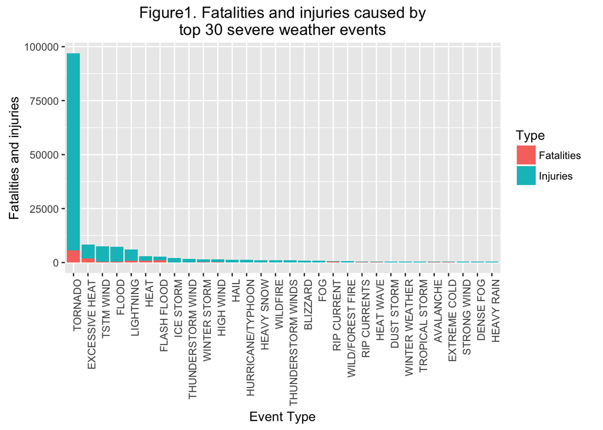

```r
ggplot(DT1topn,aes(EVTYPE,Problems,fill=Type))+geom_bar(stat="identity")+theme(axis.text.x = element_text(angle = 90,hjust=1))+xlab("Event Type")+ylab("Fatalities and injuries")+ggtitle("Figure1. Fatalities and injuries caused by\ntop 30 severe weather events")
```

### Discussion and conclusion

Figure1 reveals that the severe weather event which caused most fatalities and injuries was tornado.

### Result for economic problems caused by severe weather events

Plot the top 30 severe weather events that affect economy

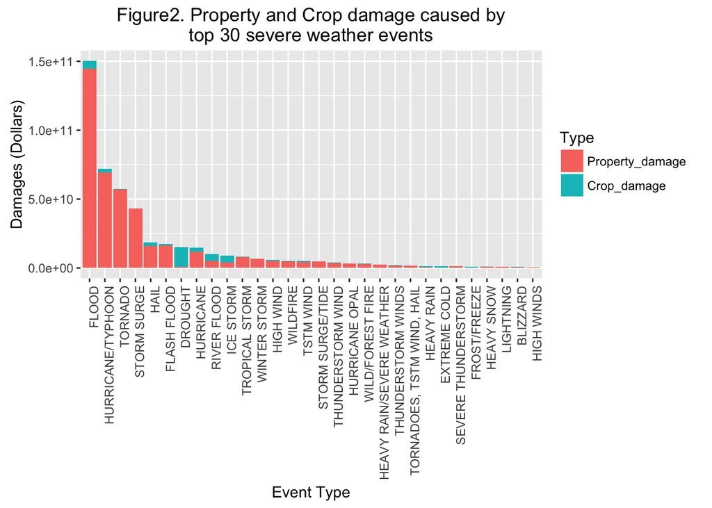

```r
ggplot(DT2topn,aes(EVTYPE,Damages,fill=Type))+geom_bar(stat="identity")+theme(axis.text.x = element_text(angle = 90,hjust=1))+xlab("Event Type")+ylab("Damages (Dollars)")+ggtitle("Figure2. Property and Crop damage caused by\ntop 30 severe weather events")
```

### Discussion and conclusion

Figure2 shows that the severe weather event which caused most economic damage was flooding. Flooding also caused the most of the property damage. But drought caused the most of the crop damage.